# HW1 Gene Expression

#### Gene Expression and Data Visualization

#### September 30th, 2025

## HW1:

For this homework, we will be working with a study from Gene Expression Omnibus (GEO) with the accession GDS2880. This is an Affymetrix microarray experiment (HGU133A array). The data researchers were investigating patient matched normal and stage 1 or stage 2 clear cell renal cell carcinoma (cRCC) tumors to provide insight into the molecular pathogenesis of cRCC. We will be conducting outlier analysis using various methods to identify aberrant samples, followed by missing value imputation to assess the accuracy of two different algorithms.

```r
# Library snippet
# Load libraries
library(GEOquery)
library(Biobase)
library(stringr)
library(dplyr)
library(tibble)
library(pheatmap)
library(dendextend)
library(ggrepel)
library(ggplot2)
library(impute)
library(reshape2)
library(AnnotationDbi)
library(hgu133a.db)
library(pcaMethods)
```

## 1)

Download and load the renal cell carcinoma data file into R. Make sure that the row names are in the correct location (Affymetrix fragment names). Look at the dimensions and verify that you have 22 arrays and 22,283 probesets.

```r
# Download dataset (will cache locally after first time)
gds <- getGEO("GDS2880")

# Convert GEO GDS object to ExpressionSet (standard Bioconductor format)
eset <- GDS2eSet(gds, do.log2 = FALSE)

# Expression matrix
expr <- Biobase::exprs(eset)

# Phenotype (sample metadata)
pheno <- Biobase::pData(eset)

# Quick checks
dim(expr)        # dimensions: probes x samples
```

```
[1] 22283    20
```

```r
head(rownames(expr))  # should show Affymetrix probe IDs
```

```
[1] "1007_s_at" "1053_at"   "117_at"    "121_at"    "1255_g_at" "1294_at"
```

```r
head(colnames(expr))  # GSM sample IDs
```

```
[1] "GSM146778" "GSM146780" "GSM146782" "GSM146784" "GSM146786" "GSM146789"
```

## 2)

Label the header columns of your data frame maintaining the GSM ID, but adding the Normal/Tumor identity.

```r
# 1) Inspect metadata columns
meta_cols <- colnames(pheno)

# 2) Fuse likely fields into a single searchable string per sample
cand_cols <- grep(
  paste(c("title","source","character","descr","disease","tissue"), collapse="|"),
  meta_cols, ignore.case = TRUE, value = TRUE
)
if (length(cand_cols) == 0) cand_cols <- meta_cols

meta_text <- apply(pheno[, cand_cols, drop=FALSE], 1, function(row) {
  paste(na.omit(as.character(row)), collapse = " | ")
})

# 3) Regex rules
re_normal <- "(^|[^a-z])normal([^a-z]|$)|adjacent normal|non[- ]?tumou?r"
re_tumor  <- "tumou?r|rcc|renal cell carcinoma|clear cell|stage\\s*[12]"

# 4) Classify
condition <- rep(NA_character_, length(meta_text))
condition[grepl(re_normal, meta_text, ignore.case = TRUE)] <- "Normal"
condition[grepl(re_tumor,  meta_text, ignore.case = TRUE) & is.na(condition)] <- "Tumor"

# 5) Report unknowns (if any)
unknown_idx <- which(is.na(condition))
if (length(unknown_idx)) {
  cat("\n[WARN] Unclassified samples — review these rows:\n")
  print(data.frame(
    GSM  = rownames(pheno)[unknown_idx],
    Meta = meta_text[unknown_idx],
    check.names = FALSE
  ), row.names = FALSE)
  # stop("Unclassified samples present; refine regex or set manual overrides.")
}

# 6) Summary & apply names
cat("\nCondition summary:\n"); print(table(condition, useNA = "ifany"))
```

```
Condition summary:
```

```
condition
Normal  Tumor
    10     10
```

```r
gsm <- rownames(pheno)
stopifnot(length(gsm) == ncol(expr))
colnames(expr) <- paste0(gsm, "_", condition)

head(colnames(expr))
```

```
[1] "GSM146778_Normal" "GSM146780_Normal" "GSM146782_Normal" "GSM146784_Normal"
[5] "GSM146786_Normal" "GSM146789_Normal"
```

## 3) Identify any outlier samples using the following visual plots:

For all plots, make sure you label the points appropriately, title plots, and label axes. You will also need to provide a legend for the correlation plot. You can use the gplots for a color gradient, or just use the default colors.

### 3a) Correlation plot (heat map)

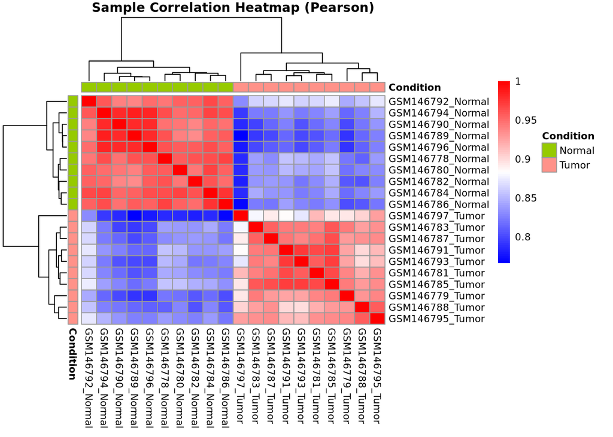

```r
# Compute correlation matrix
cors <- cor(expr, use = "pairwise.complete.obs", method = "pearson")

# Build annotation for sample groups
ann <- data.frame(Condition = condition)
rownames(ann) <- colnames(expr)

# Plot heatmap
pheatmap(cors,
         annotation_col = ann,
         annotation_row = ann,
         main = "Sample Correlation Heatmap (Pearson)",
         fontsize = 8,
         color = colorRampPalette(c("blue", "white", "red"))(100))
```

### 3b) Hierarchical clustering dendogram

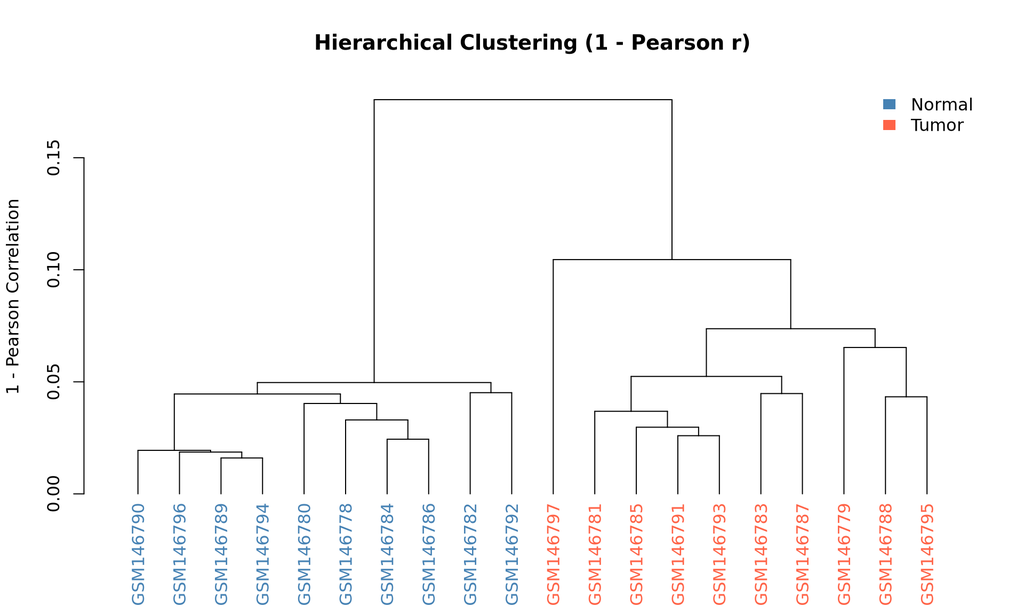

Hierarchical clustering dendrogram. Samples (GSM IDs) are ordered along the x-axis.

```r
# Distance matrix from correlation (1 - Pearson r)
D  <- as.dist(1 - cors)
hc <- hclust(D, method = "average")

# Build dendrogram
dend <- as.dendrogram(hc)

# Short GSM-only labels (strip _Normal/_Tumor)
gsm_labels <- sub("_(Normal|Tumor)$", "", colnames(expr))

# IMPORTANT: set labels *on the dend* in the clustered order
labels(dend) <- gsm_labels[order.dendrogram(dend)]

# Color labels by group
group_cols <- ifelse(condition == "Normal", "steelblue", "tomato")
labels_colors(dend) <- group_cols[order.dendrogram(dend)]

# Plot
plot(dend,
     main = "Hierarchical Clustering (1 - Pearson r)",
     xlab = "",
     ylab = "1 - Pearson Correlation",
     xaxt ="n",
     cex = 0.8)   # shrink label text a bit
legend("topright",
       legend = c("Normal","Tumor"),
       fill = c("steelblue","tomato"),
       border = NA, bty = "n")
```

### 3c) CV vs mean plot

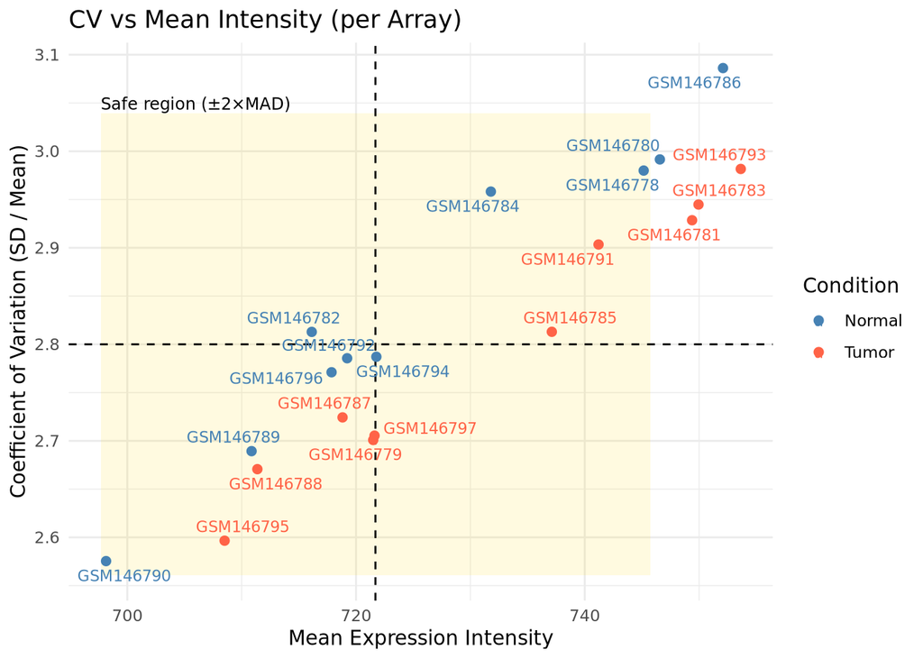

```r
# # Calculate per-sample mean and CV
samp_mean <- apply(expr, 2, function(x) mean(x, na.rm = TRUE))
samp_sd   <- apply(expr, 2, function(x) sd(x, na.rm = TRUE))
samp_cv   <- samp_sd / samp_mean

cvdf <- data.frame(
  GSMID     = sub("_(Normal|Tumor)$", "", colnames(expr)),  # short ID
  Condition = condition,
  Mean      = samp_mean,
  CV        = samp_cv
)

# Robust center & band
m_mean <- median(cvdf$Mean, na.rm = TRUE)
m_cv   <- median(cvdf$CV,   na.rm = TRUE)
b_mean <- 2 * mad(cvdf$Mean, constant = 1, na.rm = TRUE)  # width
b_cv   <- 2 * mad(cvdf$CV,   constant = 1, na.rm = TRUE)  # height

xmin <- m_mean - b_mean; xmax <- m_mean + b_mean
ymin <- m_cv   - b_cv;   ymax <- m_cv   + b_cv

ggplot(cvdf, aes(x = Mean, y = CV, color = Condition, label = GSMID)) +
  # SAFE REGION first (under points)
  annotate("rect", xmin = xmin, xmax = xmax, ymin = ymin, ymax = ymax,
           fill = "gold", alpha = 0.12, color = NA) +
  # Median reference lines
  geom_vline(xintercept = m_mean, linetype = "dashed") +
  geom_hline(yintercept = m_cv,   linetype = "dashed") +
  # Points & labels
  geom_point(size = 2) +
  ggrepel::geom_text_repel(size = 3, max.overlaps = 20) +
  # Caption label for the zone (optional)
  annotate("text", x = xmin, y = ymax, hjust = 0, vjust = -0.3,
           label = "Safe region (±2×MAD)", size = 3.2) +
  labs(title = "CV vs Mean Intensity (per Array)",
       x = "Mean Expression Intensity",
       y = "Coefficient of Variation (SD / Mean)") +
  scale_color_manual(values = c("Normal" = "steelblue", "Tumor" = "tomato")) +
  theme_minimal()
```

### Interpretation of our CV vs Mean Intesity per Array Plot

The CV versus mean plot evaluates each array’s overall **signal intensity** (x-axis) and **variability** (y-axis). To help identify well-behaved samples versus potential outliers, we overlaid a yellow “safe region” box defined using the **median absolute deviation (MAD)**.

**MAD** stands for *median absolute deviation*, which is a robust statistic for measuring spread:

$$MAD(x) = \text{median}\big(|x_i - \text{median}(x)|\big)$$

Because the median and MAD are not distorted by extreme values the way the mean and standard deviation can be, this approach provides a conservative way to flag arrays that differ too much from the majority. In this plot, the safe region is set as the **median ± 2 × MAD** for both mean intensity and CV. Arrays inside the box behave like the bulk of the data, while arrays outside are flagged as potential outliers.

### 3d) Average correlation plot

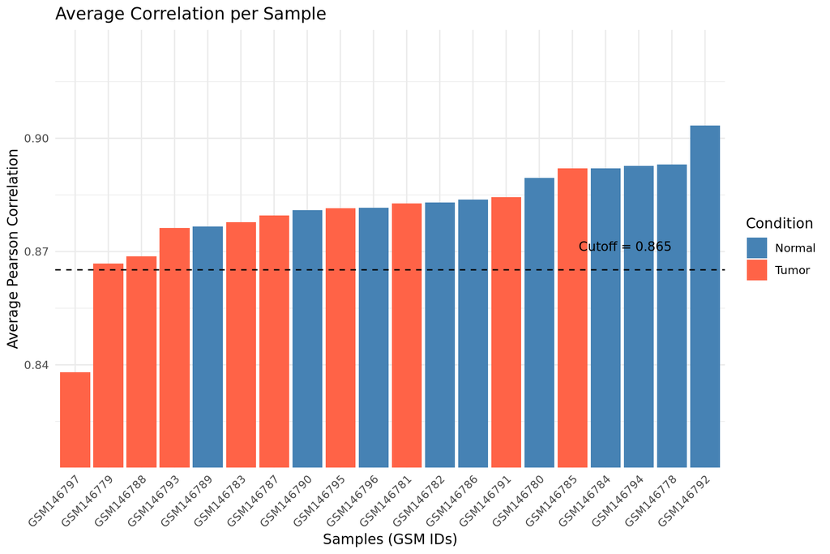

```r
# Compute average Pearson correlation per sample
cors <- cor(expr, use = "pairwise.complete.obs", method = "pearson")
avg_cor <- sapply(seq_len(ncol(cors)), function(i) mean(cors[i, -i], na.rm = TRUE))
names(avg_cor) <- sub("_(Normal|Tumor)$", "", colnames(expr))

# Condition map
cond_map <- setNames(condition, sub("_(Normal|Tumor)$", "", colnames(expr)))

acdf <- data.frame(
  GSMID = names(avg_cor),
  Condition = unname(cond_map[names(avg_cor)]),
  AvgCor = as.numeric(avg_cor),
  stringsAsFactors = FALSE
)

# Robust cutoff: median − 3×MAD
thr <- median(acdf$AvgCor, na.rm = TRUE) - 3 * mad(acdf$AvgCor, constant = 1, na.rm = TRUE)

# Dynamic y-axis: expand a little below the cutoff so it's obvious
ymin <- min(thr, min(acdf$AvgCor)) - 0.02
ymax <- max(acdf$AvgCor) + 0.02

# Plot with cutoff line and label
ggplot(acdf, aes(x = reorder(GSMID, AvgCor), y = AvgCor, fill = Condition)) +
  geom_bar(stat = "identity") +
  geom_hline(yintercept = thr, linetype = "dashed", color = "black") +
  annotate("text", x = length(acdf$GSMID) - 1, y = thr + 0.005,
           label = paste0("Cutoff = ", round(thr, 3)),
           hjust = 1, vjust = 0, size = 3.5, color = "black") +
  labs(title = "Average Correlation per Sample",
       x = "Samples (GSM IDs)",
       y = "Average Pearson Correlation") +
  coord_cartesian(ylim = c(ymin, ymax)) +
  scale_fill_manual(values = c("Normal" = "steelblue", "Tumor" = "tomato")) +
  theme_minimal() +
  theme(axis.text.x = element_text(angle = 45, hjust = 1))
```

```r
# Show the bottom 6 by average correlation
acdf <- acdf[order(acdf$AvgCor), ]
knitr::kable(head(acdf, 6), digits = 3,
             caption = "Samples with the lowest average correlations.")
```

Samples with the lowest average correlations.

|  | GSMID | Condition | AvgCor |
| --- | --- | --- | --- |
| 20 | GSM146797 | Tumor | 0.838 |
| 11 | GSM146779 | Tumor | 0.867 |
| 16 | GSM146788 | Tumor | 0.869 |
| 18 | GSM146793 | Tumor | 0.876 |
| 6 | GSM146789 | Normal | 0.877 |
| 13 | GSM146783 | Tumor | 0.878 |

### Interpretation of our Average Correlation plot

The average correlation plot summarizes each array’s mean Pearson correlation with all others. Most samples cluster tightly between **0.87–0.90**, reflecting strong overall consistency in the dataset. The robust cutoff, defined as the median − 3×MAD, was **0.865**.

## 6) Install and load the impute library. (loaded at the top)

## 7) Remove the outlier samples you identified in the first part of this assignment.

Summary of outlier decisions across QC analyses.

[output not shown]

### Outlier Selection:

Outlier detection was performed using four complementary QC methods: the correlation heatmap, hierarchical clustering dendrogram, CV vs. mean intensity plot, and the average correlation plot. Each method emphasizes a different dimension of data quality, and evaluating them together provides a defensible framework for deciding which samples to exclude.

## Filter dataset to keep only chosen samples

```r
# --- Outliers to remove ---
outliers_remove <- c("GSM146790", "GSM146786")

# Map current column names -> GSM IDs
col_gsm <- sub("_(Normal|Tumor)$", "", colnames(expr))

# Keep only non-outliers
keep_idx <- !(col_gsm %in% outliers_remove)

expr_final <- expr[, keep_idx, drop = FALSE]
condition_final <- condition[keep_idx]
names(condition_final) <- sub("_(Normal|Tumor)$", "", colnames(expr_final))

# Before/after dimensions
before_dim <- dim(expr)
after_dim <- dim(expr_final)

cat("Dimensions BEFORE filtering: ",
    before_dim[1], "probes ×", before_dim[2], "arrays\n")
```

```
Dimensions BEFORE filtering:  22283 probes × 20 arrays
```

```r
cat("Dimensions  AFTER filtering: ",
    after_dim[1], "probes ×", after_dim[2], "arrays\n\n")
```

```
Dimensions  AFTER filtering:  22283 probes × 18 arrays
```

```r
# Summary of conditions
cat("Sample counts after filtering:\n")
```

```
Sample counts after filtering:
```

```r
print(table(condition_final))
```

```
condition_final
Normal  Tumor
     8     10
```

```r
# Table of retained samples
res_tbl <- data.frame(
  GSMID = names(condition_final),
  Condition = condition_final,
  stringsAsFactors = FALSE
)
knitr::kable(res_tbl, caption = "Samples retained after removing GSM146790 and GSM146786.")
```

Samples retained after removing GSM146790 and GSM146786.

|  | GSMID | Condition |
| --- | --- | --- |
| GSM146778 | GSM146778 | Normal |
| GSM146780 | GSM146780 | Normal |
| GSM146782 | GSM146782 | Normal |
| GSM146784 | GSM146784 | Normal |
| GSM146789 | GSM146789 | Normal |
| GSM146792 | GSM146792 | Normal |
| GSM146794 | GSM146794 | Normal |
| GSM146796 | GSM146796 | Normal |
| GSM146779 | GSM146779 | Tumor |
| GSM146781 | GSM146781 | Tumor |
| GSM146783 | GSM146783 | Tumor |
| GSM146785 | GSM146785 | Tumor |
| GSM146787 | GSM146787 | Tumor |
| GSM146788 | GSM146788 | Tumor |
| GSM146791 | GSM146791 | Tumor |
| GSM146793 | GSM146793 | Tumor |
| GSM146795 | GSM146795 | Tumor |
| GSM146797 | GSM146797 | Tumor |

## 8)

Now we are going to use a couple of transcripts that were determined in this study to be indicative of normal renal function. The genes we will assess are kininogen 1 (KNG1) and aquaporin 2 (AQP2). Using either NetAffx or Gene Cards websites (or other resources, if you like), extract the probesets for these two genes. Hint: KNG1 has two while AQP2 has one. Then plot a profile plot (expression intensity vs. samples) for each probeset for these two genes. You may have to convert the data frame row to a vector to plot it. Do the plots of these genes seem to indicate normal renal function? Explain.

```r
# 1) Map genes -> all HGU133A probesets
symbols <- c("KNG1","AQP2")
all_ids <- lapply(symbols, function(sym) {
  AnnotationDbi::mapIds(
    hgu133a.db,
    keys = sym,
    keytype = "SYMBOL",
    column = "PROBEID",
    multiVals = "list"
  )
})
names(all_ids) <- symbols

# 2) Keep only probesets present in expr_final
rows_present <- rownames(expr_final)
present_ids <- lapply(all_ids, function(x) {
  if (is.null(x) || length(x) == 0) character(0) else intersect(unname(unlist(x)), rows_present)
})

found_tbl <- tibble(
  Gene = rep(names(present_ids), lengths(present_ids)),
  Probeset = unlist(present_ids, use.names = FALSE)
)

if (nrow(found_tbl) == 0) {
  stop("No probesets for KNG1/AQP2 found in this GDS subset.")
}

knitr::kable(found_tbl, caption = "Probesets present in expr_final for KNG1 and AQP2")
```

Probesets present in expr_final for KNG1 and AQP2

| Gene | Probeset |
| --- | --- |
| KNG1 | 206054_at |
| KNG1 | 217512_at |
| AQP2 | 206672_at |

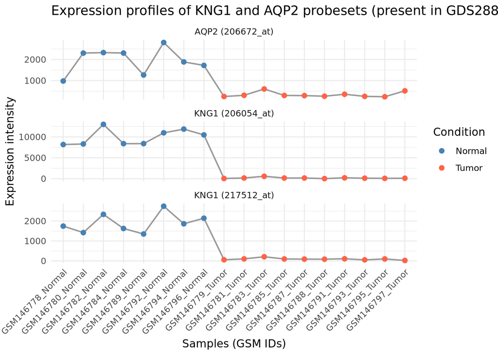

```r
# 3) Prepare data for plotting
have_ps <- unique(found_tbl$Probeset)
expr_sub <- expr_final[have_ps, , drop = FALSE]

ps2gene <- found_tbl %>% distinct(Probeset, Gene)
lab_map <- setNames(paste0(ps2gene$Gene, " (", ps2gene$Probeset, ")"), ps2gene$Probeset)

long <- reshape2::melt(expr_sub)
colnames(long) <- c("Probeset", "Sample", "Intensity")
long$Condition <- condition_final[long$Sample]
long$GeneProbe <- lab_map[long$Probeset]

# Lock sample order to the current column order of expr_final
long$Sample <- factor(long$Sample, levels = colnames(expr_final))

# 4) Plot: neutral line per facet + colored points by Condition (fixes the error)
ggplot(long, aes(x = Sample, y = Intensity)) +
  geom_line(aes(group = 1), color = "grey60", linewidth = 0.7) +
  geom_point(aes(color = Condition), size = 2) +
  facet_wrap(~ GeneProbe, scales = "free_y", ncol = 1) +
  scale_color_manual(values = c("Normal" = "steelblue", "Tumor" = "tomato")) +
  labs(title = "Expression profiles of KNG1 and AQP2 probesets (present in GDS2880 subset)",
       x = "Samples (GSM IDs)", y = "Expression intensity") +
  theme_minimal() +
  theme(axis.text.x = element_text(angle = 45, hjust = 1))
```

```r
# 5) Summary table: mean ± SD by condition for each probeset available
summary_tab <- long %>%
  group_by(GeneProbe, Condition) %>%
  summarise(
    Mean = mean(Intensity, na.rm = TRUE),
    SD   = sd(Intensity, na.rm = TRUE),
    N    = dplyr::n(),
    .groups = "drop"
  )

knitr::kable(summary_tab, digits = 3,
             caption = "KNG1/AQP2 expression by condition (only probesets present).")
```

KNG1/AQP2 expression by condition (only probesets present).

| GeneProbe | Condition | Mean | SD | N |
| --- | --- | --- | --- | --- |
| AQP2 (206672_at) | Normal | 1949.225 | 608.742 | 8 |
| AQP2 (206672_at) | Tumor | 335.420 | 124.617 | 10 |
| KNG1 (206054_at) | Normal | 9948.188 | 1891.116 | 8 |
| KNG1 (206054_at) | Tumor | 168.870 | 156.208 | 10 |
| KNG1 (217512_at) | Normal | 1903.812 | 477.758 | 8 |
| KNG1 (217512_at) | Tumor | 91.100 | 48.594 | 10 |

### Interpretation of KNG1 and AQP2 Expression Profiles

The expression profiles of **KNG1** and **AQP2** probesets highlight a stark contrast between Normal kidney tissue and tumor samples. Both **KNG1 probesets** (206054_at and 217512_at) show consistently high expression across Normal samples, with mean values of ~9948 and ~1904, respectively. In Tumor samples, expression collapses almost entirely, with means below 200, indicating that the gene is effectively silenced in clear cell carcinoma. This dramatic downregulation is consistent with the role of kininogen 1 in maintaining normal renal and vascular function, and its loss may reflect dedifferentiation in the tumor state.

The **AQP2 probeset** (206672_at) shows a similar pattern. Expression is robust in Normal kidney arrays (mean ~1949) but markedly reduced in Tumor arrays (mean ~335). AQP2 encodes aquaporin-2, a water channel essential for proper renal tubular water reabsorption. Its suppression in tumor tissue suggests a breakdown of normal renal epithelial specialization, consistent with the transition to a malignant phenotype.

Overall, both genes behave as expected markers of **normal renal physiology**. Their strong expression in Normal samples and loss in Tumor samples provides internal validation of the dataset and reinforces the biological insight that clear cell renal cell carcinoma is associated with loss of differentiated renal function.

## 9) We want to assess the accuracy of missing value imputation. So assign the KNG1 probeset (206054_at) an NA value, only for array GSM146784. Be sure to first save the original value before replacing it with an NA. Also cast the data frame to a matrix to run this function.

```r
# Work on a matrix (required by impute.knn)
expr_mat <- as.matrix(expr_final)

target_probe  <- "206054_at"   # KNG1
target_gsm_id <- "GSM146784"   # GSM ID without suffix

# --- Resolve the actual column name that matches this GSM (handles _Normal/_Tumor suffix) ---
col_match <- which(sub("_(Normal|Tumor)$", "", colnames(expr_mat)) == target_gsm_id)
if (length(col_match) != 1) {
  stop("Could not uniquely match GSM column for ", target_gsm_id,
       ". Matches found: ", paste(colnames(expr_mat)[col_match], collapse = ", "))
}
col_name <- colnames(expr_mat)[col_match]

# --- Check the probeset exists ---
row_match <- match(target_probe, rownames(expr_mat))
if (is.na(row_match)) {
  stop("Probeset ", target_probe, " not found in expr_mat rownames.")
}

# --- Save original value and replace with NA ---
original_value <- expr_mat[row_match, col_match]
cat("Original value for", target_probe, "in", col_name, "=", original_value, "\n")
```

```
Original value for 206054_at in GSM146784_Normal = 8385.3
```

```r
expr_mat[row_match, col_match] <- NA
cat("After replacement, value is:", expr_mat[row_match, col_match], "\n")
```

```
After replacement, value is: NA
```

## 10) Now estimate the missing values in the array using 6 nearest neighbors and Euclidean distance with the impute.knn() function.

```r
# impute.knn uses Euclidean distance by default; rows=genes, cols=samples
imp <- impute.knn(expr_mat, k = 6)
```

[output not shown]

[output cut: 20 more lines]

[output not shown]

```r
# Extract imputed matrix and value
imputed_mat <- imp$data
imputed_value <- imputed_mat[row_match, col_match]

cat("Imputed value for", target_probe, "in", col_name, "=", imputed_value, "\n")
```

```
Imputed value for 206054_at in GSM146784_Normal = 9206.967
```

## 11) Look at the value that was imputed for your gene and calculate the relative error of this value using the actual value that you saved.

```r
# Make sure original_value and imputed_value exist from Q9 and Q10
cat("Original value:", original_value, "\n")
```

```
Original value: 8385.3
```

```r
cat("Imputed value :", imputed_value, "\n")
```

```
Imputed value : 9206.967
```

```r
# Relative error calculation
relative_error <- abs(imputed_value - original_value) / abs(original_value)

cat("Relative error =", round(relative_error, 4), "\n")
```

```
Relative error = 0.098
```

**Interpretation.**  
The KNN imputation for **KNG1 (206054_at)** in **GSM146784** produced a relative error of 0.098. In absolute terms, this error represents roughly a 9.8% deviation from the true intensity value. Considering that microarray probe intensities in this dataset span from the low hundreds to nearly 10,000, an error of this magnitude is relatively small and unlikely to affect downstream analyses such as clustering or differential expression. This demonstrates that KNN imputation was able to recover a value that closely approximated the original measurement, preserving the integrity of the data. In practical terms, the imputed value maintained the overall profile of KNG1 expression across samples, suggesting that neighbor-based imputation is an effective strategy for handling isolated missing values in highly correlated microarray datasets.

## 12) Now impute the missing values using the SVD imputation method. This is in the pcaMethods package and the function is called pca ()with method svdImpute and set nPcs=9. To retrive the output matrix, see the help file.

```r
# pcaMethods expects observations in rows (samples) and variables in columns (probes)
set.seed(123)                  # reproducibility
X_obs_rows <- t(expr_mat)      # samples x probes

# SVD impute with 9 PCs; center=TRUE, scale="none" per instructions
svd_fit <- pca(X_obs_rows, method = "svdImpute", nPcs = 9, center = TRUE, scale = "none")

# Completed data (same shape as X_obs_rows), then map back to probes x samples
X_completed <- completeObs(svd_fit)        # samples x probes
expr_mat_svd <- t(X_completed)             # probes x samples

# Extract the SVD-imputed value at the same cell (remember the transpose)
svd_imputed_value <- X_completed[col_match, row_match]

cat("SVD-imputed value for 206054_at in",
    colnames(expr_mat)[col_match], "=", svd_imputed_value, "\n")
```

```
SVD-imputed value for 206054_at in GSM146784_Normal = 10898.28
```

```r
# Compute relative errors
svd_rel_error <- abs(svd_imputed_value - original_value) / abs(original_value)
cat("SVD relative error =", round(svd_rel_error, 4), "\n")
```

```
SVD relative error = 0.2997
```

**Interpretation.**  
The SVD imputation method (`nPcs = 9`) yielded a relative error of 0.2997, corresponding to a 30% deviation from the true intensity of **KNG1 (206054_at)** in **GSM146784**. This error was notably higher than the error observed with KNN, indicating that the reconstructed value diverged more from the actual measurement. The difference arises because SVD relies on a global low-rank approximation of the dataset, which captures dominant expression patterns but can oversmooth localized variation. In the context of microarray data, where individual probes may vary in ways not well explained by global structure, this smoothing can reduce accuracy. While the SVD result remained in the general range of the true value, the elevated relative error suggests that SVD was less effective than KNN at accurately recovering the missing intensity for this specific probeset.

## 13) Finally, plot a gene profile plot of the probeset for this gene, where the two different imputed values are represented as different colored points and the actual value is a third point.

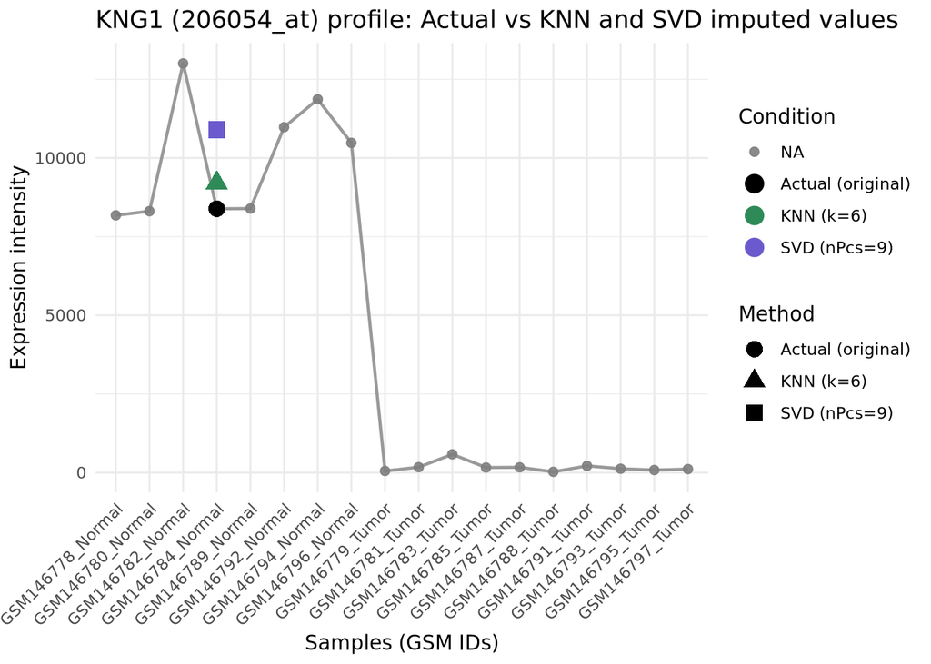

```r
# Use the original expression matrix (expr_final) so we have the true series
profile <- data.frame(
  Sample    = colnames(expr_final),
  Intensity = as.numeric(expr_final[target_probe, colnames(expr_final)]),
  Condition = factor(condition_final[colnames(expr_final)],
                     levels = c("Normal","Tumor"))
)

# Keep plotting order identical to matrix column order
profile$Sample <- factor(profile$Sample, levels = colnames(expr_final))

# Identify the exact column name for the GSM target (with suffix)
target_sample_colname <- colnames(expr_mat)[col_match]

# --- Three points at GSM146784: Actual, KNN, SVD ---
points_df <- data.frame(
  Sample    = factor(rep(target_sample_colname, 3), levels = levels(profile$Sample)),
  Value     = c(original_value, imputed_value, svd_imputed_value),
  Method    = factor(c("Actual (original)","KNN (k=6)","SVD (nPcs=9)"),
                     levels = c("Actual (original)","KNN (k=6)","SVD (nPcs=9)"))
)

# --- Plot ---
ggplot(profile, aes(x = Sample, y = Intensity, group = 1)) +
  geom_line(color = "grey60", linewidth = 0.8) +
  geom_point(aes(color = Condition), size = 2, alpha = 0.9) +
  # overlay the three special points
  geom_point(data = points_df,
             aes(x = Sample, y = Value, shape = Method, color = Method),
             size = 3.5, stroke = 1.1) +
  scale_color_manual(values = c("Normal" = "steelblue", "Tumor" = "tomato",
                                "Actual (original)" = "black",
                                "KNN (k=6)" = "#2E8B57",       # green-ish
                                "SVD (nPcs=9)" = "#6A5ACD")) + # slateblue
  scale_shape_manual(values = c("Actual (original)" = 16,  # solid circle
                                "KNN (k=6)" = 17,          # triangle
                                "SVD (nPcs=9)" = 15)) +    # square
  labs(title = "KNG1 (206054_at) profile: Actual vs KNN and SVD imputed values",
       x = "Samples (GSM IDs)", y = "Expression intensity") +
  theme_minimal() +
  theme(axis.text.x = element_text(angle = 45, hjust = 1),
        legend.position = "right")
```

## Conclusion

Validation using **KNG1** and **AQP2** confirmed biological integrity of the dataset. Both genes, markers of normal renal function, were strongly expressed in Normal samples but markedly reduced in Tumors, reflecting the expected loss of differentiated kidney function in clear cell carcinoma.

The imputation analysis highlighted differences between local and global methods. For **KNG1 (206054_at) in GSM146784**, KNN imputation (k = 6) produced a relative error of ~0.098 (≈9.8%), whereas SVD imputation (nPcs = 9) produced a larger error of ~0.300 (≈30%). This threefold difference shows that nearest-neighbor methods can more accurately recover missing expression values in correlated microarray datasets, while SVD, which relies on global structure, may oversmooth individual probe behavior.

Overall, this exercise demonstrated that robust QC and careful imputation are not only technical steps but also crucial for protecting the integrity of patient data. By integrating multiple QC perspectives, validating known physiological markers, and comparing imputation strategies quantitatively, we modeled how data-driven decisions directly shape the reliability of biological insights in cancer genomics.